# Kaggle Titanic Competition - Relatório

Lilia Sampaio

February 9, 2015

### Importando datasets

Para essa análise dois datasets foram fornecidos, um de treino chamado *train* e o que utilizaremos para testar nosso modelo de predição chamado *test*.

```r
train <- read.csv("train.csv")
test <- read.csv("test.csv")
```

### Como os dados estão estruturados?

Os dados de treino são os que utilizaremos como base para realizar nossas predições. Nesse caso, é importante saber como eles estão estruturados e quais as variáveis disponíveis nesse conjunto de daods, para que assim possamos decidir o que utilizar para criar um bom modelo.

```r
str(train)
```

```
## 'data.frame':    891 obs. of  12 variables:
##  $ PassengerId: int  1 2 3 4 5 6 7 8 9 10 ...
##  $ Survived   : int  0 1 1 1 0 0 0 0 1 1 ...
##  $ Pclass     : int  3 1 3 1 3 3 1 3 3 2 ...
##  $ Name       : Factor w/ 891 levels "Abbing, Mr. Anthony",..: 109 191 354 273 16 555 516 625 413 577 ...
##  $ Sex        : Factor w/ 2 levels "female","male": 2 1 1 1 2 2 2 2 1 1 ...
##  $ Age        : num  22 38 26 35 35 NA 54 2 27 14 ...
##  $ SibSp      : int  1 1 0 1 0 0 0 3 0 1 ...
##  $ Parch      : int  0 0 0 0 0 0 0 1 2 0 ...
##  $ Ticket     : Factor w/ 681 levels "110152","110413",..: 524 597 670 50 473 276 86 396 345 133 ...
##  $ Fare       : num  7.25 71.28 7.92 53.1 8.05 ...
##  $ Cabin      : Factor w/ 148 levels "","A10","A14",..: 1 83 1 57 1 1 131 1 1 1 ...
##  $ Embarked   : Factor w/ 4 levels "","C","Q","S": 4 2 4 4 4 3 4 4 4 2 ...
```

### Análise dos dados

Partimos então para um entendimento básico dos dados, e a partir de consultas e visualizações simples sobre os mesmo, conseguimos ver o que eles nos dizem em relação à sobrevivência ou não dos passageiros considerados.

**Sobrevivência X Óbito** *(0 para faleceu, 1 para sobreviveu)*

Total de pessoas que não sobreviveram X sobreviveram

```r
table(train$Survived)
```

```
##
##   0   1
## 549 342
```

Porcentagem de pessoas que não sobreviveram X sobreviveram

```r
prop.table(table(train$Survived))
```

```
##
##         0         1
## 0.6161616 0.3838384
```

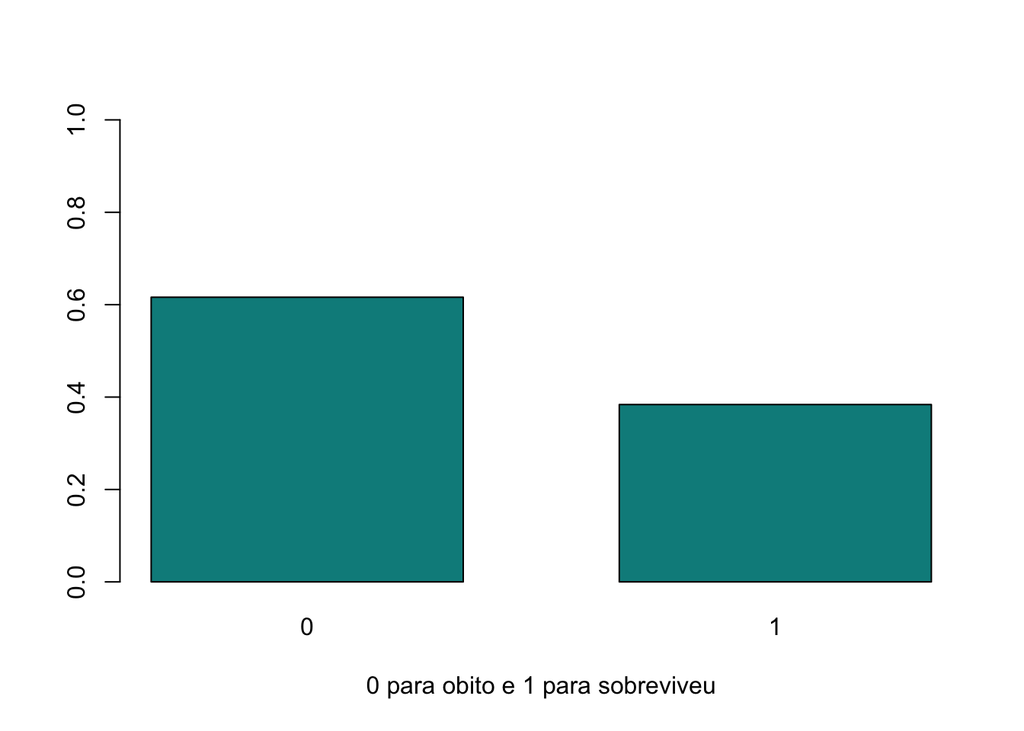

Sem a utilização dos conceitos de Árvores de Decisão, a partir dessa análise simples, onde apenas ~38% dos passageiros sobreviveu, podemos considerar no nosso conjunto *test* que nenhum dos passageiros sobreviveu. Submetendo esse conjunto de teste ao Kaggle, temos uma precisão de 0.62679.

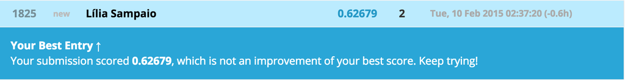

**Sobrevivência X Óbito - Homem X Mulher** *(0 para faleceu, 1 para sobreviveu)*

Para tentar melhorar a precisão da nossa precisão, outra variável que pode fazer a diferença é a referente ao sexo dos passageiros. Nesse caso, podemos agora relacionar os passageiros que sobreviveram com o seu sexo para saber se um sexo prevalece sobre o outro, por exemplo.

Porcentagem de homens e mulheres que sobreviveram X não sobreviveram

```r
prop.table(table(train$Sex, train$Survived),1)
```

```
##
##                  0         1
##   female 0.2579618 0.7420382
##   male   0.8110919 0.1889081
```

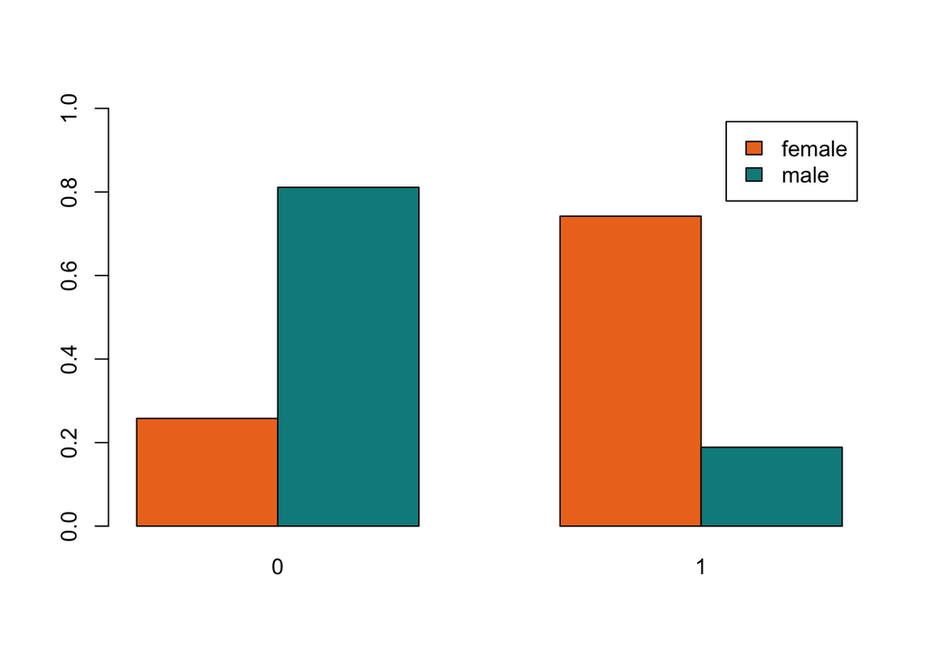

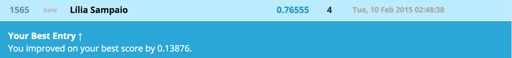

### Análise de atributos secundários

**Análise da idade dos passageiros**

```r
summary(train$Age)
```

```
##    Min. 1st Qu.  Median    Mean 3rd Qu.    Max.    NA's
##    0.42   20.12   28.00   29.70   38.00   80.00     177
```

Ainda podemos criar atributos secundários a partir de existentes, como por exemplo uma variável *Child* para ver se as crianças sobreviveram a uma taxa maior do que os adultos, por exemplo.

Adicionando variável *Child*:

```r
train$Child <- 0
train$Child[train$Age < 18] <- 1
```

A partir disso, podemos calcular a proporção de passageiros que sobreviveu, e era adulto ou criança, homem ou mulher, como vemos abaixo *(0 para adulto, 1 para criança)*:

```r
aggregate(Survived ~ Child + Sex, data=train, FUN=sum)
```

```
##   Child    Sex Survived
## 1     0 female      195
## 2     1 female       38
## 3     0   male       86
## 4     1   male       23
```

```r
aggregate(Survived ~ Child + Sex, data=train, FUN=function(x) {sum(x)/length(x)})
```

```
##   Child    Sex  Survived
## 1     0 female 0.7528958
## 2     1 female 0.6909091
## 3     0   male 0.1657033
## 4     1   male 0.3965517
```

Além dessas, várias outras caracteristicas e variáveis podem ser extraídas dos dados e consideradas na predição, como veremos a seguir utilizando uma árvore de decisão.

### Criando Árvore de Decisão

Usar uma árvore de decisão é uma maneira de automatizar os processos anteriores para a obtenção de uma predição com mais acurácia. Nesse caso iremos considerar as variáveis *Pclass*, *Sex*, *Age*, *SibSp*, *Parch*, *Fare* e *Embarked*.

[figure not shown]

```r
fit <- rpart(Survived ~ Pclass + Sex + Age + SibSp + Parch + Fare + Embarked, data=train, method="class")
fancyRpartPlot(fit)
```

**Criando modelo de predição a ser submetido**

```r
prediction <- predict(fit, test, type = "class")
submit_final <- data.frame(PassengerId = test$PassengerId, Survived = prediction)
write.csv(submit_final, file = "myfirstdtree.csv", row.names = FALSE)
```

**Resultado final do Kaggle**

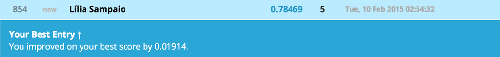